# MT Cars: Simple Linear Regression Diagnostics App

Unam Bakumeni

12 February 2017

# About the Application

The purpose of the ‘MT Cars: Simple Linear Regression Diagnostics App’ is to teach users about diagnostic plots that can be run on a simply linear regression model using the MT Cars dataset readily available in R. A user selects the target variable and then an input variable. Following this, the app creates a regression model and displays the diagnostic plots for the model. The app also explains how each plot can be interpreted in order to determine whether the model is good or not.

# The Data Set

The data set used in the app is pulled from the 1974 Motor Trend US magazine and consists of the following variables for 32 cars:

```r
head(mtcars)
```

```
##                    mpg cyl disp  hp drat    wt  qsec vs am gear carb
## Mazda RX4         21.0   6  160 110 3.90 2.620 16.46  0  1    4    4
## Mazda RX4 Wag     21.0   6  160 110 3.90 2.875 17.02  0  1    4    4
## Datsun 710        22.8   4  108  93 3.85 2.320 18.61  1  1    4    1
## Hornet 4 Drive    21.4   6  258 110 3.08 3.215 19.44  1  0    3    1
## Hornet Sportabout 18.7   8  360 175 3.15 3.440 17.02  0  0    3    2
## Valiant           18.1   6  225 105 2.76 3.460 20.22  1  0    3    1
```

# Default Regression Model and Diagnostics

By default, the app creates a simple linear regrssion model using the cars displacement to predict miles per gallon. Below is an example of the diagnostic plots created with the default model. The app fully explains how to inpertret each plot

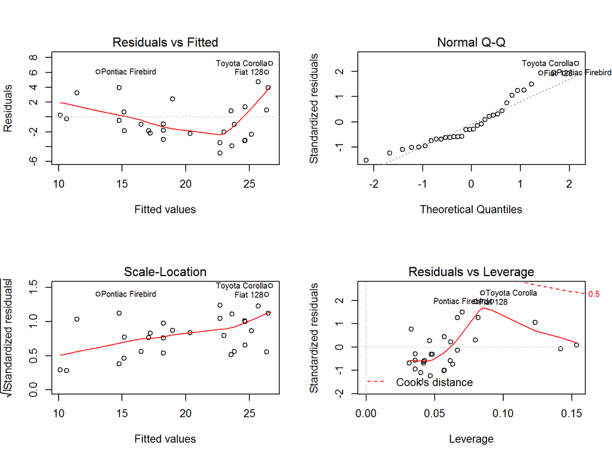

# Accessing the app

You can access the app at the following [link](https://unam-b.shinyapps.io/DDP_Shiny_App/)